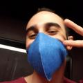

# Nathanael Rolim

## Ele/Dele | He/Him

- Email
- [ChronoScrat](https://github.com/ChronoScrat/)
- [NathanaelRolim](https://linkedin.com/in/nathanaelrolim)
- [@NathanaelRolim](https://twitter.com/nathanaelrolim)
- [PudimDEV](https://pudim.dev)

## About Me

Hello! I’m Nathanael Rolim, a student of International Relations at the University of São Paulo. In some online communities, I go by the **ChronoScrat** username. As a student, I have a keen interest in researching public opinion and government, both domestically (in my home country of Brazil), and internationally.

One of my core values is the belief that I can use simple tools that already exist in order to improve and facilitate people’s tasks. Many of such approaches involve creating applications inside Google Sheets.

## Job Experience

current 2022

### Associate Client Lead

São Paulo, Brazil

dunnhumby

- Main tasks: data analysis, weekly and monthly report preparation and presentation, client-focused data-based problem solving.

2022 2021

### Intern

São Paulo, Brazil

dunnhumby

- Main tasks: data analysis, weekly and monthly report preparation and presentation, client-focused data-based problem solving.

## Education

current 2018

### BA International Relations

São Paulo, Brazil

University of São Paulo

- Undergraduate course in International Relations, with a strong focus on International Trade, development, and state affairs.

## Skills

R

Web Design

Javascript

Python

## Languages

- Portuguese
- English
- French
- Spanish